# PfSI Example

# PfSI Example

This vignette shows how to run the MACRO model in this package: the PfSI course of infection (CoI) which is coupled to a 1-day time-step Ross-Macdonald (RM) mosquito model.

## One Simulation Run

The first thing we will want to do is load the necessary packages and set output paths. When we set the output path we check if the directory exists, and if it does, we *clear out* any existing files that are there (so please don’t set to your root directory)! We do this to avoid errors when reading output. At this point we also go ahead and set the random seed, because this version of MACRO uses R’s random number generator through the C API because of its ease of use and quality.

```r
# output path
path <- "output/"
if(!dir.exists(path)){
  dir.create(path)
} else {
  files <- list.files(path)
  if(length(files) > 0){
    for(f in files){
      file.remove(paste0(path,f))
    }
  }
}

# seed
set.seed(42L)

library(macro.pfsi)
```

```r
# Matrix for sparse mosquito diffusion matrices
library(Matrix)
# tidyverse and Hmisc for output visualization; I prefer to use tidyverse but the output can be analyzed with base plots just fine
library(tidyverse)
library(Hmisc)
```

The next thing we do is set up parameters and initial conditions of the simulation. The next code chunk sets up the patch/node parameters and the mosquito parameters. We assume a simple landscape of 5 nodes. We don’t want to change any of the default parameters so we call `pfsi_parameters` without any arguments. Please note that the human movement matrix is dense while the mosquito matrix *psi* is sparse. This is because the TaR (time-at-risk) model for humans assumes a dense distribution of time over possible sites; while being more memory intensive this should not slow down computation significantly because movement events are scheduled individually. Mosquito movement is handled via matrix-vector multiplication, so a sparse *psi* can help significantly. In this example we don’t allow mosquitoes to move.

```r
# vector of parameters
pfsi_pars <- pfsi_parameters()

# set up patches (n is how many patches we have)
n <- 5
# movement matrix for humans is uniform over possible destinations.
move <- matrix(data = 1/(n-1),nrow = n,ncol = n)
diag(move) <- 0
patch_pars <- patches_parameters(move = move,bWeightZoo = rep(0,n),bWeightZootox = rep(0,n),reservoir = rep(F,n),res_EIR = rep(0,n))

# mosquitos
psi <- Matrix::sparseMatrix(i = {},j = {},x = 0.0,dims = c(n,n))
diag(psi) <- rep(1,n)
mosy_pars <- mosquito_rm_conpars(N = n,lambda = matrix(50,nrow = 365,ncol = n),
                                 psi = psi,EIP = rep(11,365),M = rep(450,n),Y = rep(0,n),Z = rep(0,n))
```

The next thig we do is set up the parameters for the human population, and also vaccine events (if any). If no vaccines are being simulated, just pass an empty list (as in the commented out line). Here each patch has 1,000 residents and a PfPR (parasite prevalence) of 0.5. We used uniform biting weights, but could have used any distribution on the positive reals with finite mean (Gamma, log-Normal, Weibull, etc). Please note that in the call to `human_pfsi_conpars`, which builds the packet of information needed by the human object constructor in C++, we can select either Poisson or Negative Binomial biting distribution at the *individual* level via the argument `bite_algorithm`. Here we use Poisson biting, but see the help (`?human_pfsi_conpars`) for information on how to change.

```r
# humans
patch_sizes <- rep(1e3,n) # number of people in each patch
pfpr <- rep(0.5,n) # malaria prevalence in each patch
nh <- sum(patch_sizes) # total num of humans

# sample S or I for each person
init_state <- unlist(mapply(FUN = function(n,pr){
  sample(x = c("I","S"),size = n,replace = T,prob = c(pr,1-pr))
},n=patch_sizes,pr=pfpr,SIMPLIFY = F))

# where the people go (0-indexed for c++)
patch_id <- rep(0:(n-1),times=patch_sizes)

# uniform biting weights; this could follow any density on the positive reals (gamma, log-normal, weibull, etc.)
bweights <- rep(1,nh)

# the data structure that will be passed down to C++ to construct the human pop
human_pars <- vector("list",nh)
for(i in 1:nh){
  human_pars[[i]] <- human_pfsi_conpars(id = i-1,home_patch_id = patch_id[i],
                                        trip_duration = rep(3,n),trip_frequency = 1/20,bweight = bweights[i],
                                        age = 20,state = init_state[i],bite_algorithm = 0)
}

# vaccinations (can uncomment the code below to vaccinate 25% of the population at day 500)
# vaxx_pars <- list()
vaxx_id <- sample(x = 0:(nh-1),size = nh*0.25,replace = F)
vaxx_pars <- lapply(X = vaxx_id,FUN = function(id){
  vaccination_pfsi_conpars(id = id,t = 5e2,treat = T,type = "PE")
})
```

Now all the parameters have been specified so we are ready to sample a single trajectory from the stochastic model. We just set up the data structure that the C++ logger needs to know where to write out data and then we can run MACRO. After that we show some visualizations of the trajectory. The visualization is just for a confirmation that the model ran correctly and not intended for analysis, which will depend on the specific questions being investigated.

```r
log_pars <- list()
h_inf <- paste0(path,"pfsi.csv")
log_pars[[1]] <- list(outfile = h_inf,key = "pfsi",
                      header = paste0(c("time","patch",unlist(lapply(c("S","I","P"),function(x){paste0(x,c("_visitor","_resident_home","_resident_away"))})),"incidence_resident","incidence_traveller"),collapse = ",")
                    )
mosy <- paste0(path,"mosy.csv")
log_pars[[2]] <- list(outfile = mosy,key = "mosquito",
                      header = paste0(c("time","state",paste0("patch",1:n)),collapse = ","))

run_macro(tmax = 1e3,
          human_pars = human_pars,
          mosquito_pars = mosy_pars,
          patch_pars = patch_pars,
          model_pars = pfsi_pars,
          log_streams = log_pars,
          vaxx_events = vaxx_pars,
          verbose = T)

pfsi <- readr::read_csv("output/pfsi.csv")
```

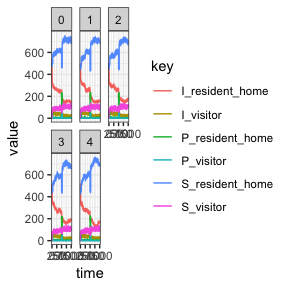

```r
pfsi_pr <- pfsi %>%
  select(-ends_with("away")) %>%
  select(-starts_with("incidence")) %>%
  gather(key, value, -time,-patch)

ggplot(pfsi_pr) +
  geom_line(aes(x=time,y=value,color=key)) +
  facet_wrap(. ~ patch) +
  theme_bw()
```

## Multiple Simulation Runs

Here we use the same initial conditions and sample 100 trajectories from the stochastic model.

```r
# run ensemble
nrun <- 1e2
tsteps <- 1e3
pb <- txtProgressBar(min = 1,max = nrun)
for(i in 1:nrun){

  log_pars <- list()
  h_inf <- paste0(path,"pfsi_",i,".csv")
  log_pars[[1]] <- list(outfile = h_inf,key = "pfsi",
                        header = paste0(c("time","patch",unlist(lapply(c("S","I","P"),function(x){paste0(x,c("_visitor","_resident_home","_resident_away"))})),"incidence_resident","incidence_traveller"),collapse = ","))
  mosy <- paste0(path,"mosy_",i,".csv")
  log_pars[[2]] <- list(outfile = mosy,key = "mosquito",
                        header = paste0(c("time","state",paste0("patch",1:n)),collapse = ","))

  run_macro(tmax = tsteps,
            human_pars = human_pars,
            mosquito_pars = mosy_pars,
            patch_pars = patch_pars,
            model_pars = pfsi_pars,
            log_streams = log_pars,
            vaxx_events = vaxx_pars,
            verbose = FALSE)
  setTxtProgressBar(pb,i)
}
```

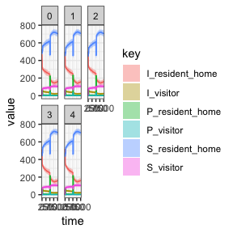

```r
pfsi_ensemble <-
  list.files(path = "output/",pattern = "pfsi_[[:digit:]]+.csv") %>%
  map_df(~read_csv(paste0("output/",.)),.id = "run")
pfsi_ensemble_pr <- pfsi_ensemble %>%
  select(-ends_with("away")) %>%
  select(-starts_with("incidence")) %>%
  gather(key, value, -time,-patch,-run)

ggplot(pfsi_ensemble_pr,aes(x=time,y=value,color=key,fill=key)) +
  stat_summary(fun.data = median_hilow,fun.args = list(conf.int = 0.95),geom = "ribbon",alpha=0.4,color=NA) +
  stat_summary(geom="line", fun.y="mean") +
  facet_wrap(. ~ patch) +
  guides(color = FALSE) +
  theme_bw()
```